# Find The Right Cigar

**You struggle to find a cigar that fits your budget but also your quality expectations ?**  
In this project, I propose to build a cigars dataset from scratch. Then I will save it as an Excel file that you will be able to filter by your own in order to find cigars that will fit your expectations.

**In this notebook I will use :**

- Web scraping for collecting data on a website.
- Object oriented programming.
- Data cleaning for making the datas standardized and usable.
- Data analysis for checking data quality and getting insights.

### 1) Import Python librairies

```python
from bs4 import BeautifulSoup
import requests
import re
import numpy as np
import pandas as pd
from matplotlib import pyplot as plt

import warnings;
warnings.filterwarnings('ignore')

%matplotlib inline
```

### 2) Web Scraping

Cigars are made in almost all latin american and caribbean countries but there are four main producers :

- Cuba.
- Dominican Republic.
- Nicaragua.
- Honduras.

```python
url = 'https://www.maison-du-cigare.be/cigares/'
terroirs = ['cubains','dominicains','honduriens','nicaraguayens']
```

```python
all_brands = []


for terroir in terroirs:


    page = requests.get(url + terroir + '/')
    soup = BeautifulSoup(page.content,'html.parser')
    tableau = soup.find_all(class_='flex_column_table av-equal-height-column-flextable -flextable')



    for i in range(len(tableau)):

        for j in tableau[i].find_all('a'):
            text = j.text
            text = text.replace("«\xa0","").replace("\xa0»"," ")
            all_brands.append([text,terroir])
```

```python
print(all_brands[5:18:2])
```

```
[['Edicion Limitada & Reserva', 'cubains'], ['H. Upmann', 'cubains'], ['Jose L. Piedra', 'cubains'], ['La Flor de Cano', 'cubains'], ['Montecristo Línea 1935', 'cubains'], ['Partagas', 'cubains'], ['Punch', 'cubains']]
```

```python
len(all_brands)
```

```
130
```

```python
all_cigars = []

for liste in all_brands:



    page = requests.get('https://www.maison-du-cigare.be/cigares/'+liste[1]+'/'+liste[0]+'/')
    soup = BeautifulSoup(page.content,'html.parser')
    tableau = soup.find_all(class_='av-catalogue-item-inner')



    for i in range(len(tableau)):

        for j in tableau[i].find_all('div',{'class':'av-catalogue-title av-cart-update-title'}):
            l1 = []
            l1.append(liste[0])
            l1.append(liste[1])
            text = j.text
            text = text.replace("«\xa0","").replace("\xa0»","")
            l1.append(text)

            for k in tableau[i].find_all('span',{'class':"woocommerce-Price-amount amount"}):
                text = k.text
                text = text.replace("€","").replace(",",".")
                l1.append(text)

            for n in tableau[i].find_all('div',{'class':'av-catalogue-content'}):
                text = n.text
                text = text.replace(",",".")
                l2 = re.findall(r"[-+]?\d*\.\d+|\d+",text)
                l1 += l2



        all_cigars.append(l1)
```

### 3) Data quality check & data cleaning

**We can observe in each list the following ranking :**

```python
print(all_cigars[:5])
```

[output not shown]

```python
len(all_cigars[1])
```

```
8
```

```python
len8 = 0
other = 0

for sublist in all_cigars:

    if len(sublist) == 8:
        len8 += 1

    else:
        other += 1

print(other*100/len8)
```

```
0.0
```

### 4) Dataset Creation

```python
column_name = ['brand', 'origin', 'name','unit_price_eur', 'box_price_eur', 'cig_per_box', 'diameter_cm', 'length_cm']

df = pd.DataFrame(all_cigars, columns=column_name)
```

```python
df
```

|  | brand | origin | name | unit_price_eur | box_price_eur | cig_per_box | diameter_cm | length_cm |
| --- | --- | --- | --- | --- | --- | --- | --- | --- |
| 0 | Bolivar | cubains | Coronas Junior | 7.40 | 185.00 | 25 | 1.7 | 11.0 |
| 1 | Bolivar | cubains | Royal Coronas | 12.50 | 312.50 | 25 | 2.0 | 12.4 |
| 2 | Bolivar | cubains | Belicosos Finos | 14.60 | 365.00 | 25 | 2.0 | 14.0 |
| 3 | Cohiba | cubains | Siglo I | 12.40 | 310.00 | 25 | 1.6 | 10.2 |
| 4 | Cohiba | cubains | Siglo II | 15.50 | 387.50 | 25 | 1.7 | 12.9 |
| ... | ... | ... | ... | ... | ... | ... | ... | ... |
| 495 | Tatuaje | nicaraguayens | Tattoo Adivino (Gordo) | 7.50 | 375.00 | 50 | 2.3 | 13.8 |
| 496 | Tatuaje | nicaraguayens | Cojonu 2003 | 16.00 | 400.00 | 25 | 2.1 | 16.5 |
| 497 | Tatuaje | nicaraguayens | Gran Cojonu | 18.50 | 222.00 | 12 | 2.5 | 16.5 |
| 498 | The T | nicaraguayens | Robusto | 15.50 | 310.00 | 20 | 2.0 | 12.9 |
| 499 | The T | nicaraguayens | Toro | 16.50 | 330.00 | 20 | 2.0 | 15.4 |

500 rows × 8 columns

```python
for col in  ["unit_price_eur","box_price_eur","cig_per_box","diameter_cm","length_cm"]:
    df[col] = pd.to_numeric(df[col], errors='coerce')
```

```python
df.describe()
```

|  | unit_price_eur | box_price_eur | cig_per_box | diameter_cm | length_cm |
| --- | --- | --- | --- | --- | --- |
| count | 500.000000 | 500.000000 | 500.000000 | 500.000000 | 500.000000 |
| mean | 14.082400 | 238.079600 | 20.372000 | 1.998000 | 13.773700 |
| std | 9.289636 | 139.904708 | 7.263824 | 0.267543 | 2.227806 |
| min | 2.300000 | 23.000000 | 4.000000 | 1.000000 | 8.250000 |
| 25% | 8.575000 | 152.375000 | 20.000000 | 1.900000 | 12.500000 |
| 50% | 11.500000 | 214.800000 | 20.000000 | 2.000000 | 13.500000 |
| 75% | 15.925000 | 300.000000 | 25.000000 | 2.200000 | 15.200000 |
| max | 65.000000 | 995.000000 | 55.000000 | 2.600000 | 21.500000 |

```python
terroirs_dict = {'cubains':'Cuba','dominicains':'Dominican Rep.',
                 'honduriens':'Honduras','nicaraguayens':'Nicaragua'}

for i in range(len(df)):
    if df.iat[i,1] in terroirs_dict:
        df.iat[i,1] = terroirs_dict[df.iat[i,1]]
    else:
        pass
```

```python
df.head()
```

|  | brand | origin | name | unit_price_eur | box_price_eur | cig_per_box | diameter_cm | length_cm |
| --- | --- | --- | --- | --- | --- | --- | --- | --- |
| 0 | Bolivar | Cuba | Coronas Junior | 7.4 | 185.0 | 25 | 1.7 | 11.0 |
| 1 | Bolivar | Cuba | Royal Coronas | 12.5 | 312.5 | 25 | 2.0 | 12.4 |
| 2 | Bolivar | Cuba | Belicosos Finos | 14.6 | 365.0 | 25 | 2.0 | 14.0 |
| 3 | Cohiba | Cuba | Siglo I | 12.4 | 310.0 | 25 | 1.6 | 10.2 |
| 4 | Cohiba | Cuba | Siglo II | 15.5 | 387.5 | 25 | 1.7 | 12.9 |

```python
df.to_excel('cigars_dataset.xlsx', index=False)
```

### 5) Data Analysis

```python
df[['origin','unit_price_eur','diameter_cm','length_cm']].groupby(['origin']).describe().transpose()
```

|  | origin | Cuba | Dominican Rep. | Honduras | Nicaragua |
| --- | --- | --- | --- | --- | --- |
| unit_price_eur | count | 119.000000 | 166.000000 | 58.000000 | 157.000000 |
|  | mean | 16.094538 | 15.237048 | 10.770690 | 12.559873 |
|  | std | 12.332080 | 9.375013 | 5.308484 | 6.843253 |
|  | min | 2.300000 | 2.600000 | 4.500000 | 4.700000 |
|  | 25% | 8.600000 | 9.500000 | 8.125000 | 8.500000 |
|  | 50% | 13.600000 | 12.900000 | 10.000000 | 10.500000 |
|  | 75% | 17.500000 | 17.000000 | 11.000000 | 14.500000 |
|  | max | 65.000000 | 54.000000 | 33.000000 | 45.000000 |
| diameter_cm | count | 119.000000 | 166.000000 | 58.000000 | 157.000000 |
|  | mean | 1.867227 | 1.987952 | 2.044828 | 2.090446 |
|  | std | 0.258453 | 0.277826 | 0.206196 | 0.242261 |
|  | min | 1.000000 | 1.000000 | 1.500000 | 1.500000 |
|  | 25% | 1.700000 | 1.900000 | 2.000000 | 2.000000 |
|  | 50% | 1.900000 | 2.000000 | 2.000000 | 2.100000 |
|  | 75% | 2.050000 | 2.200000 | 2.100000 | 2.200000 |
|  | max | 2.300000 | 2.500000 | 2.400000 | 2.600000 |
| length_cm | count | 119.000000 | 166.000000 | 58.000000 | 157.000000 |
|  | mean | 13.348739 | 13.793675 | 13.962069 | 14.005096 |
|  | std | 2.338327 | 2.323589 | 2.064217 | 2.065678 |
|  | min | 9.000000 | 8.250000 | 9.000000 | 8.800000 |
|  | 25% | 11.800000 | 12.500000 | 12.700000 | 12.700000 |
|  | 50% | 12.900000 | 13.400000 | 14.000000 | 14.100000 |
|  | 75% | 14.450000 | 15.200000 | 15.300000 | 15.300000 |
|  | max | 19.400000 | 21.500000 | 18.700000 | 19.000000 |

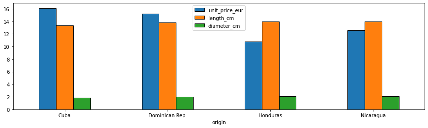

```python
dmean = df[['origin','unit_price_eur','length_cm','diameter_cm']].groupby(['origin']).mean()

fig = dmean.plot.bar(Edgecolor='black',figsize=(15,4))
fig.tick_params(axis='x', labelrotation = 0)
```

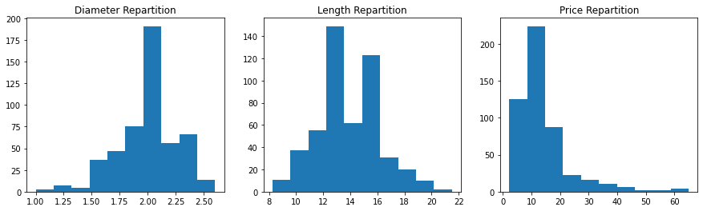

```python
fig, (ax1, ax2, ax3) = plt.subplots(1,3,figsize=(15,4))

ax1.hist(df[['diameter_cm']])
ax1.set_title('Diameter Repartition')

ax2.hist(df[['length_cm']])
ax2.set_title('Length Repartition')

ax3.hist(df[['unit_price_eur']])
ax3.set_title('Price Repartition')
```

**Top 5 : Less and more expensive brands**

```python
company = df[['brand','unit_price_eur']].groupby(['brand']).mean()
```

```python
col = ['unit_price_eur']
print("5 most expensive brands :",company.nlargest(5, col))
print("")
print("5 less expensive brands :",company.nsmallest(5, col))
```

```
5 most expensive brands :                 unit_price_eur
brand
Jose L. Piedra       56.562500
Cohiba Behike        56.500000
Cusano               44.383333
La Ribera            36.750000
La Estancia          31.000000

5 less expensive brands :                       unit_price_eur
brand
Quintero                    3.060000
San Pedro de Macoris        4.814286
Casa Fernandez              5.250000
Vega Fina                   6.107143
Quesada                     6.500000
```

### 6) Application

```python
def find_cigars(PriceMin=df['unit_price_eur'].min(),
                PriceMax=df['unit_price_eur'].max(),
                DiamMin=df['diameter_cm'].min(),
                DiamMax=df['diameter_cm'].max(),
                LenMin=df['length_cm'].min(),
                LenMax=df['length_cm'].max(),
                Origin=['Cuba','Nicaragua','Dominican Rep.','Honduras']):

    choices =  df.loc[(df['unit_price_eur'] <= PriceMax) &
                  (df['unit_price_eur'] >= PriceMin) &
                  (df['diameter_cm'] <= DiamMax) &
                  (df['diameter_cm'] >= DiamMin) &
                  (df['length_cm'] <= LenMax) &
                  (df['length_cm'] >= LenMin) &
                  (df['origin'].isin(Origin))]

    return choices
```

```python
find_cigars(PriceMin=5,PriceMax=6,Origin=['Cuba'])
```

|  | brand | origin | name | unit_price_eur | box_price_eur | cig_per_box | diameter_cm | length_cm |
| --- | --- | --- | --- | --- | --- | --- | --- | --- |
| 23 | H. Upmann | Cuba | Half Corona | 5.2 | 130.0 | 25 | 1.8 | 9.0 |
| 24 | H. Upmann | Cuba | Majestic | 5.2 | 130.0 | 25 | 1.6 | 14.0 |
| 67 | Partagas | Cuba | Mille Fleurs | 5.1 | 51.0 | 10 | 1.7 | 12.9 |
| 94 | Romeo y Julieta | Cuba | Mille Fleurs | 5.2 | 52.0 | 10 | 1.7 | 12.9 |
| 115 | Vegueros | Cuba | Mananitas | 5.5 | 88.0 | 16 | 1.8 | 10.1 |